# ggPredict()

Workshop on Statistics for Linguistics

Sky Onosson, University of Manitoba

# ggPredict() Tutorial

The `ggPredict()` function is used to create interactive plots which allow you to display information about datapoints in the plot using your mouse. This tutorial is by Keon-Woong Moon, published online at https://cran.r-project.org/web/packages/ggiraphExtra/vignettes/ggPredict.html

The tutorial begins here:

To reproduce this document, you have to install R package ggiraphExtra from github.

```r
if(!require(devtools)){install.packages("devtools")}
library(devtools)
devtools::install_github("cardiomoon/ggiraphExtra")
```

# 1 Linear regression Model

## 1.1 Simple linear regression model

In univariate regression model, you can use scatter plot to visualize model. For example, you can make simple linear regression model with data radial included in package moonBook. The radial data contains demographic data and laboratory data of 115 pateints performing IVUS(intravascular ultrasound) examination of a radial artery after tansradial coronary angiography. The NTAV(normalized total atheroma volume measured by intravascular ultrasound(IVUS) in cubic mm) is a quantitative measurement of atherosclerosis. Suppose you want to predict the amount of atherosclerosis(NTAV) from age.

```r
require(moonBook)   # for use of data radial
fit=lm(NTAV~age,data=radial)
summary(fit)
```

```
##
## Call:
## lm(formula = NTAV ~ age, data = radial)
##
## Residuals:
##     Min      1Q  Median      3Q     Max
## -45.231 -14.626  -4.803   9.685 100.961
##
## Coefficients:
##             Estimate Std. Error t value Pr(>|t|)
## (Intercept)  44.3398    14.6251   3.032  0.00302 **
## age           0.3848     0.2271   1.694  0.09302 .
## ---
## Signif. codes:  0 '***' 0.001 '**' 0.01 '*' 0.05 '.' 0.1 ' ' 1
##
## Residual standard error: 23.94 on 113 degrees of freedom
## Multiple R-squared:  0.02477,    Adjusted R-squared:  0.01614
## F-statistic:  2.87 on 1 and 113 DF,  p-value: 0.09302
```

You can get the regression equation from summary of regression model:

`y=0.38*x+44.34`

> **Note from Sky:** `y=0.38` is derived from the Estimate for “age” in the summary, and `x+44.34` is derived from the Estimate for the Intercept.

You can visualize this model easly with `ggplot2` package.

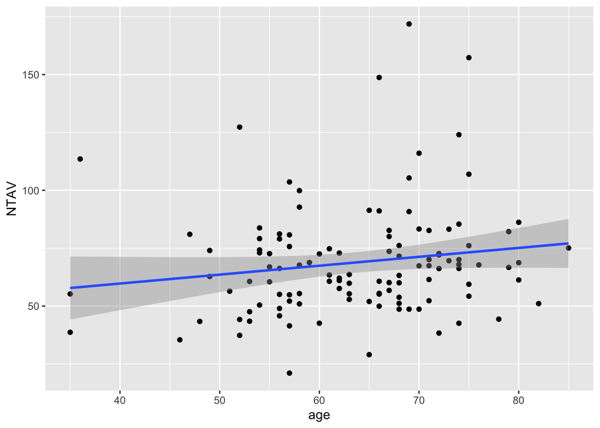

```r
require(ggplot2)
ggplot(radial,aes(y=NTAV,x=age))+geom_point()+geom_smooth(method="lm")
```

You can make interactive plot easily with `ggPredict()` function included in `ggiraphExtra` package.

```r
require(ggiraph)
require(ggiraphExtra)
require(plyr)
ggPredict(fit,se=TRUE,interactive=TRUE)
```

[interactive chart not shown]

With this plot, you can identify the points and see the regression equation with your mouse. Multiple regression model without interaction

You can make a regession model with two predictor variables. Now you can use age and sex as predcitor variables.

```r
fit1=lm(NTAV~age+sex,data=radial)
summary(fit1)
```

```
##
## Call:
## lm(formula = NTAV ~ age + sex, data = radial)
##
## Residuals:
##     Min      1Q  Median      3Q     Max
## -46.025 -12.687  -1.699   5.784  89.419
##
## Coefficients:
##             Estimate Std. Error t value Pr(>|t|)
## (Intercept)  17.8697    14.3846   1.242  0.21673
## age           0.6379     0.2134   2.989  0.00344 **
## sexM         20.5476     4.1943   4.899 3.27e-06 ***
## ---
## Signif. codes:  0 '***' 0.001 '**' 0.01 '*' 0.05 '.' 0.1 ' ' 1
##
## Residual standard error: 21.82 on 112 degrees of freedom
## Multiple R-squared:  0.1969, Adjusted R-squared:  0.1825
## F-statistic: 13.73 on 2 and 112 DF,  p-value: 4.659e-06
```

From the result of regression analysis, you can get regression regression equations of female and male patients :

For female patient, `y=0.64*x+17.87` For male patient, `y=0.64*x+38.42`

> **Note from Sky:** `y=0.64` is derived from the Estimate for “age” in the summary, and `x+17.87` for female patients is derived from the Estimate for the Intercept, and `x+38.42` for male patients is derived from adding the Estimate for the Intercept to the Estimate for “sexM”.

You can visualize this model with `ggplot2` package.

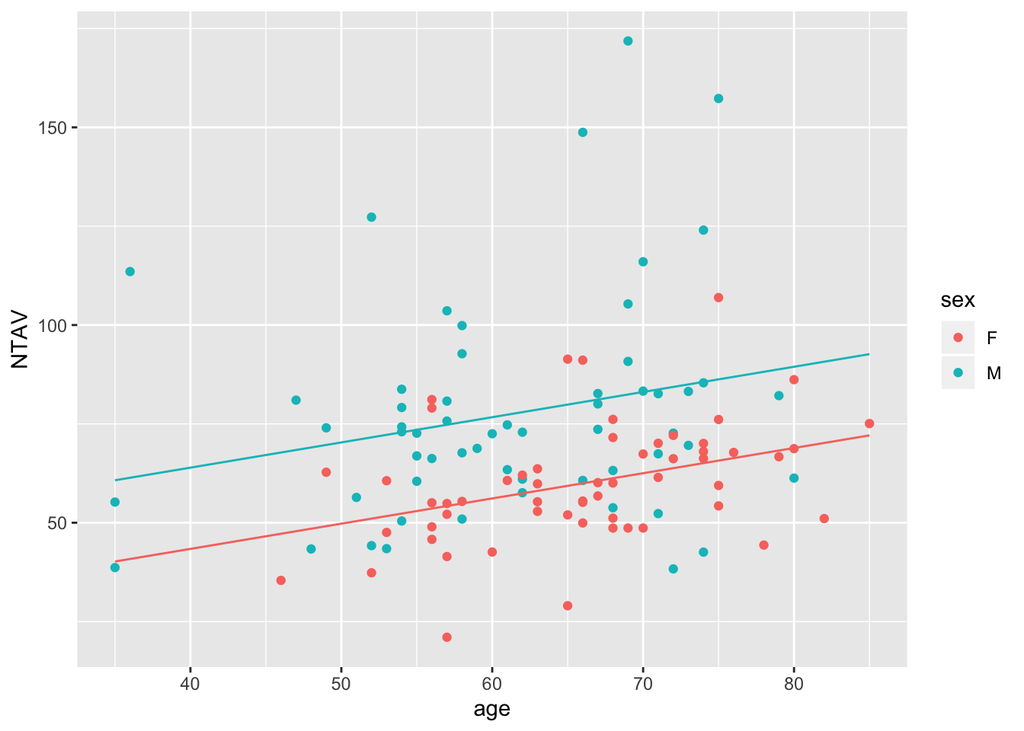

```r
equation1=function(x){coef(fit1)[2]*x+coef(fit1)[1]}
equation2=function(x){coef(fit1)[2]*x+coef(fit1)[1]+coef(fit1)[3]}

ggplot(radial,aes(y=NTAV,x=age,color=sex))+geom_point()+
        stat_function(fun=equation1,geom="line",color=scales::hue_pal()(2)[1])+
        stat_function(fun=equation2,geom="line",color=scales::hue_pal()(2)[2])
```

You can make interactive plot easily with ggPredict() function included in ggiraphExtra package.

```r
ggPredict(fit1,se=TRUE,interactive=TRUE)
```

[interactive chart not shown]

You can make a regession model with two predictor variables with interaction. Now you can use age and DM(diabetes mellitus) and interaction between age and DM as predcitor variables.

```r
fit2=lm(NTAV~age*DM,data=radial)
summary(fit2)
```

```
##
## Call:
## lm(formula = NTAV ~ age * DM, data = radial)
##
## Residuals:
##     Min      1Q  Median      3Q     Max
## -44.094 -15.115  -4.093   9.102 102.024
##
## Coefficients:
##             Estimate Std. Error t value Pr(>|t|)
## (Intercept)  49.6463    16.8660   2.944  0.00395 **
## age           0.2925     0.2648   1.105  0.27174
## DM          -20.8618    34.8936  -0.598  0.55115
## age:DM        0.3453     0.5353   0.645  0.52026
## ---
## Signif. codes:  0 '***' 0.001 '**' 0.01 '*' 0.05 '.' 0.1 ' ' 1
##
## Residual standard error: 24.1 on 111 degrees of freedom
## Multiple R-squared:  0.0292, Adjusted R-squared:  0.002966
## F-statistic: 1.113 on 3 and 111 DF,  p-value: 0.347
```

The regression equation in this model are as follows: For patients without DM(DM=0), the intercept is `49.65` and the slope is `0.29`. For patients with DM(DM=1), the intercept is `49.65-20.86` and the slope is `0.29+0.35`.

> For patients without DM(DM=0), `y=0.29*x+49.65` For patients without DM(DM=1), `y=0.64*x+28.78`

You can visualize this model with `ggplot2`.

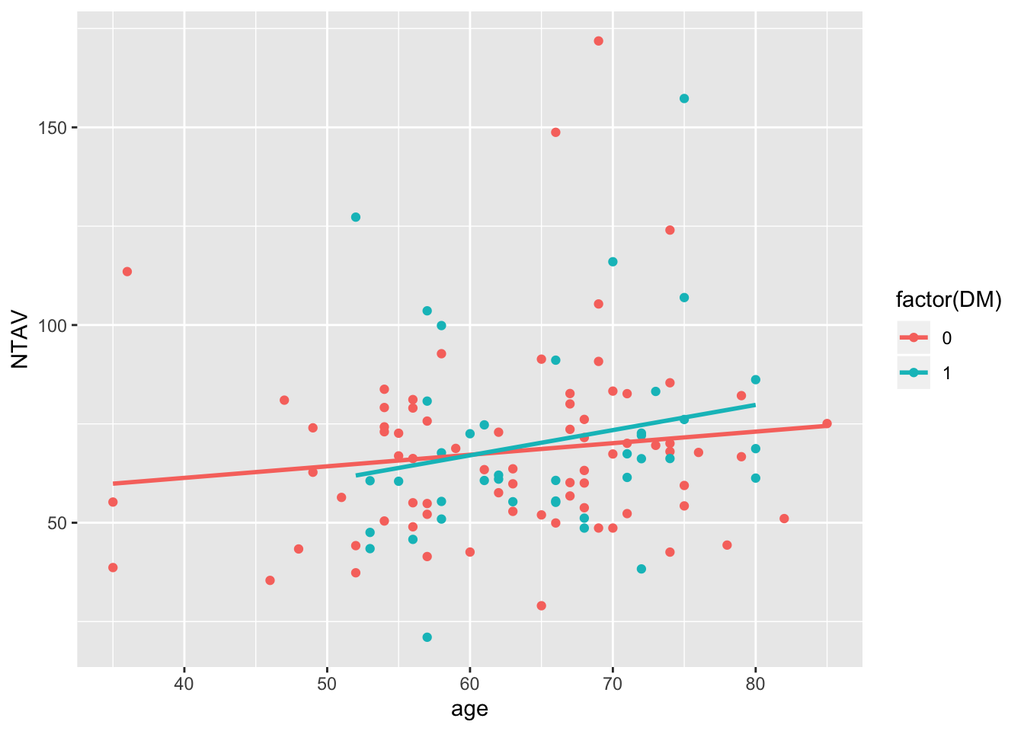

```r
ggplot(radial,aes(y=NTAV,x=age,color=factor(DM)))+geom_point()+stat_smooth(method="lm",se=FALSE)
```

You can make interactive plot easily with `ggPredict()` function included in `ggiraphExtra` package.

```r
ggPredict(fit2,colorAsFactor = TRUE,interactive=TRUE)
```

[interactive chart not shown]

## 1.2 Multiple regression model with two continuous predictor variables with or without interaction

You can make a regession model with two continuous predictor variables. Now you can use age and weight(body weight in kilogram) as predcitor variables.

```r
fit3=lm(NTAV~age*weight,data=radial)
summary(fit3)
```

```
##
## Call:
## lm(formula = NTAV ~ age * weight, data = radial)
##
## Residuals:
##     Min      1Q  Median      3Q     Max
## -48.482 -13.815  -2.079   6.886  93.187
##
## Coefficients:
##              Estimate Std. Error t value Pr(>|t|)
## (Intercept)  37.60533  111.46748   0.337    0.736
## age          -0.32698    1.69737  -0.193    0.848
## weight       -0.10416    1.74620  -0.060    0.953
## age:weight    0.01468    0.02687   0.546    0.586
##
## Residual standard error: 22.91 on 111 degrees of freedom
## Multiple R-squared:  0.1222, Adjusted R-squared:  0.09851
## F-statistic: 5.152 on 3 and 111 DF,  p-value: 0.00226
```

From the analysis, you can get the regression equation for a patient with body weight 40kg, the intercept is `37.61+(-0.10416)*40` and the slope is `-0.33+0.01468*40`

For bodyweight 40kg, `y=0.26*x+33.44` For bodyweight 50kg, `y=0.41*x+32.4` For bodyweight 90kg, `y=0.99*x+28.23`

To visualize this model, the simple `ggplot` command shows only one regression line.

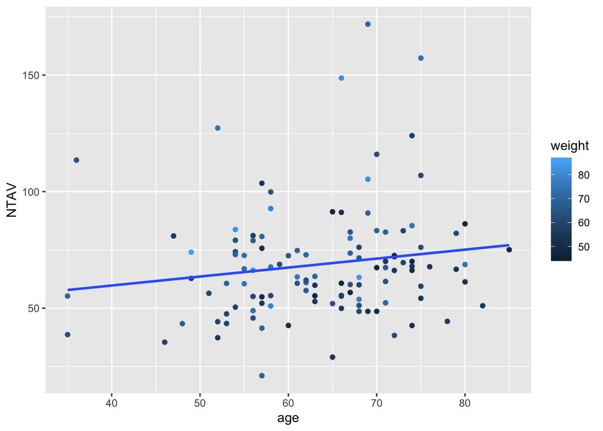

```r
ggplot(radial,aes(y=NTAV,x=age,color=weight))+geom_point()+stat_smooth(method="lm",se=FALSE)
```

You can easily show this model with `ggPredict()` function.

```r
ggPredict(fit3,interactive=TRUE)
```

[interactive chart not shown]

## 1.3 Multiple regression model with three predictor variables

You can make a regession model with three predictor variables. Now you can use age and weight(body weight in kilogram) and HBP(hypertension) as predcitor variables.

```r
fit4=lm(NTAV~age*weight*HBP,data=radial)
summary(fit4)
```

```
##
## Call:
## lm(formula = NTAV ~ age * weight * HBP, data = radial)
##
## Residuals:
##     Min      1Q  Median      3Q     Max
## -43.453 -14.125  -3.226   7.724  88.126
##
## Coefficients:
##                  Estimate Std. Error t value Pr(>|t|)
## (Intercept)      64.11678  155.82328   0.411    0.682
## age              -0.67650    2.47339  -0.274    0.785
## weight           -0.39685    2.37886  -0.167    0.868
## HBP            -101.94261  238.52253  -0.427    0.670
## age:weight        0.01686    0.03804   0.443    0.658
## age:HBP           1.27972    3.64467   0.351    0.726
## weight:HBP        1.52494    3.75529   0.406    0.685
## age:weight:HBP   -0.01666    0.05777  -0.288    0.774
##
## Residual standard error: 22.8 on 107 degrees of freedom
## Multiple R-squared:  0.1626, Adjusted R-squared:  0.1078
## F-statistic: 2.967 on 7 and 107 DF,  p-value: 0.006982
```

To visualize this model, you can make a faceted plot with `ggPredict()` function. You can see the regression equation of each subset with hovering your mouse on the regression lines.

```r
ggPredict(fit4,interactive = TRUE)
```

[interactive chart not shown]

# 2 Logistic regression model

## 2.1 Multiple logistic regression model with two predictor variables

### 2.1.1 Model with interaction

You can use `glm()` function to make a logistic regression model. The GBSG2 data in package TH.data contains data from German Breast Cancer Study Group 2. Suppose you want to predict survival with number of positive nodes and hormonal therapy.

```r
require(TH.data) # for use data GBSG2
fit5=glm(cens~pnodes*horTh,data=GBSG2,family=binomial)
summary(fit5)
```

```
##
## Call:
## glm(formula = cens ~ pnodes * horTh, family = binomial, data = GBSG2)
##
## Deviance Residuals:
##     Min       1Q   Median       3Q      Max
## -2.7892  -1.0208  -0.7573   1.2288   1.6667
##
## Coefficients:
##                 Estimate Std. Error z value Pr(>|z|)
## (Intercept)     -0.55368    0.13942  -3.971 7.15e-05 ***
## pnodes           0.08672    0.02172   3.993 6.53e-05 ***
## horThyes        -0.69833    0.25394  -2.750  0.00596 **
## pnodes:horThyes  0.06306    0.03899   1.617  0.10582
## ---
## Signif. codes:  0 '***' 0.001 '**' 0.01 '*' 0.05 '.' 0.1 ' ' 1
##
## (Dispersion parameter for binomial family taken to be 1)
##
##     Null deviance: 939.68  on 685  degrees of freedom
## Residual deviance: 887.69  on 682  degrees of freedom
## AIC: 895.69
##
## Number of Fisher Scoring iterations: 4
```

You can easily visualize this modelwith `ggPredict` funition().

```r
ggPredict(fit5,se=TRUE,interactive=TRUE,digits=3)
```

[interactive chart not shown]

### 2.1.2 Model without interaction

You can make multiple logistic regression model with no interaction between predictor variables.

```r
fit6=glm(cens~pnodes+horTh,data=GBSG2,family=binomial)
summary(fit6)
```

```
##
## Call:
## glm(formula = cens ~ pnodes + horTh, family = binomial, data = GBSG2)
##
## Deviance Residuals:
##     Min       1Q   Median       3Q      Max
## -3.1301  -0.9988  -0.8131   1.2243   1.5923
##
## Coefficients:
##             Estimate Std. Error z value Pr(>|z|)
## (Intercept) -0.65312    0.12764  -5.117 3.10e-07 ***
## pnodes       0.10871    0.01817   5.984 2.17e-09 ***
## horThyes    -0.39283    0.16827  -2.334   0.0196 *
## ---
## Signif. codes:  0 '***' 0.001 '**' 0.01 '*' 0.05 '.' 0.1 ' ' 1
##
## (Dispersion parameter for binomial family taken to be 1)
##
##     Null deviance: 939.68  on 685  degrees of freedom
## Residual deviance: 890.40  on 683  degrees of freedom
## AIC: 896.4
##
## Number of Fisher Scoring iterations: 4
```

```r
ggPredict(fit6,se=TRUE,interactive=TRUE,digits=3)
```

[interactive chart not shown]

## 2.2 Multiple logistic regression model with two continuous predictor variables

You can make multiple logistic regression model with two continuous variables with interaction.

```r
fit7=glm(cens~pnodes*age,data=GBSG2,family=binomial)
summary(fit7)
```

```
##
## Call:
## glm(formula = cens ~ pnodes * age, family = binomial, data = GBSG2)
##
## Deviance Residuals:
##     Min       1Q   Median       3Q      Max
## -3.1166  -0.9791  -0.8979   1.2464   1.5204
##
## Coefficients:
##               Estimate Std. Error z value Pr(>|z|)
## (Intercept) -0.4992499  0.6092464  -0.819    0.413
## pnodes       0.0738909  0.0910865   0.811    0.417
## age         -0.0053115  0.0112587  -0.472    0.637
## pnodes:age   0.0006119  0.0016679   0.367    0.714
##
## (Dispersion parameter for binomial family taken to be 1)
##
##     Null deviance: 939.68  on 685  degrees of freedom
## Residual deviance: 895.69  on 682  degrees of freedom
## AIC: 903.69
##
## Number of Fisher Scoring iterations: 4
```

```r
ggPredict(fit7,interactive=TRUE)
```

[interactive chart not shown]

You can adjust the number of regression lines with parameter `colorn`. for eample you can draw 100 regression lines with following R command.

```r
ggPredict(fit7,interactive=TRUE,colorn=100,jitter=FALSE)
```

[interactive chart not shown]

You can make multiple logistic regression model with three predictor variables.

```r
fit8=glm(cens~pnodes*age*horTh,data=GBSG2,family=binomial)
summary(fit8)
```

```
##
## Call:
## glm(formula = cens ~ pnodes * age * horTh, family = binomial,
##     data = GBSG2)
##
## Deviance Residuals:
##     Min       1Q   Median       3Q      Max
## -2.7666  -1.0199  -0.7665   1.2383   1.6824
##
## Coefficients:
##                       Estimate Std. Error z value Pr(>|z|)
## (Intercept)         -0.8802840  0.7117496  -1.237    0.216
## pnodes               0.0998775  0.0987607   1.011    0.312
## age                  0.0064011  0.0135780   0.471    0.637
## horThyes            -0.1449532  1.5091354  -0.096    0.923
## pnodes:age          -0.0002568  0.0018397  -0.140    0.889
## pnodes:horThyes      0.0207995  0.2335465   0.089    0.929
## age:horThyes        -0.0103794  0.0267799  -0.388    0.698
## pnodes:age:horThyes  0.0007661  0.0041094   0.186    0.852
##
## (Dispersion parameter for binomial family taken to be 1)
##
##     Null deviance: 939.68  on 685  degrees of freedom
## Residual deviance: 887.38  on 678  degrees of freedom
## AIC: 903.38
##
## Number of Fisher Scoring iterations: 4
```

```r
ggPredict(fit8,interactive=TRUE,colorn=100,jitter=FALSE)
```

[interactive chart not shown]